# Practice makes perfect

### Filter rows

You can extract rows from a data frame in several ways in base R. The first way is to use a number specifying the position of a row. The code below slices the first row out from the gapminder data using an index. Notice that the syntax is slightly different from what we used to pull and select in the earlier sections. Instead of a single value within the square bracket notation there is now space for two that are separated by a comma. The syntax can be illustrated as follows - `df[rows, columns]`. The part before the comma is used to subset rows while that after the comma is used for columns. In our case, we would like to slice the entire first row. So we have left the subset command for columns empty which selects all of them.

```r
gapminder[1, ]
```

| country | continent | year | lifeExp | pop | gdpPercap |
| --- | --- | --- | --- | --- | --- |
| Afghanistan | Asia | 1952 | 28.801 | 8425333 | 779.4453 |

The equivalent in `dplyr` is as follows.

```r
slice(.data = gapminder, 1)
```

| country | continent | year | lifeExp | pop | gdpPercap |
| --- | --- | --- | --- | --- | --- |
| Afghanistan | Asia | 1952 | 28.801 | 8425333 | 779.4453 |

or

```r
gapminder %>%
    slice(1)
```

| country | continent | year | lifeExp | pop | gdpPercap |
| --- | --- | --- | --- | --- | --- |
| Afghanistan | Asia | 1952 | 28.801 | 8425333 | 779.4453 |

You can also specify a range of rows to slice. The code below gives first to the 10th row in the data.

```r
gapminder[1:10, ]
```

| country | continent | year | lifeExp | pop | gdpPercap |
| --- | --- | --- | --- | --- | --- |
| Afghanistan | Asia | 1952 | 28.801 | 8425333 | 779.4453 |
| Afghanistan | Asia | 1957 | 30.332 | 9240934 | 820.8530 |
| Afghanistan | Asia | 1962 | 31.997 | 10267083 | 853.1007 |
| Afghanistan | Asia | 1967 | 34.020 | 11537966 | 836.1971 |
| Afghanistan | Asia | 1972 | 36.088 | 13079460 | 739.9811 |
| Afghanistan | Asia | 1977 | 38.438 | 14880372 | 786.1134 |
| Afghanistan | Asia | 1982 | 39.854 | 12881816 | 978.0114 |
| Afghanistan | Asia | 1987 | 40.822 | 13867957 | 852.3959 |
| Afghanistan | Asia | 1992 | 41.674 | 16317921 | 649.3414 |
| Afghanistan | Asia | 1997 | 41.763 | 22227415 | 635.3414 |

**Task 11**: Use `seq()` to create a vector of even numbers from 2 to 20. Use this vector to slice the even rows until 20 (including 20). Use the base syntax for this.

**Task 12**: Use `seq()` to create a vector of even numbers from 2 to 20. Use this vector to slice the even rows until 20 (including 20). Use the `slice()` function for this.

**Note**: We learnt earlier that we can use either the `$` (dollar) or the `[[]]` (double square bracket) operators to perform a simplifying subset i.e. take a data frame and pull out a column from it as an atomic vector. This is not possible for a row i.e. we cannot take a single row from a dataframe using either of these notations and covert it to an atomic vector. There are other ways in which you could do this, however, in general this is not advisable since you would be coercing a lot of different columns that hold potentially data of different types into an atomic vector with a single data type.

In most cases, we will use some sort of condition to filter rows. For instance, lets say that we only want the years greater than 1990 from out gapminder data. We can do this as follows.

```r
gapminder[gapminder$year > 1990, ] %>%
    head()
```

| country | continent | year | lifeExp | pop | gdpPercap |
| --- | --- | --- | --- | --- | --- |
| Afghanistan | Asia | 1992 | 41.674 | 16317921 | 649.3414 |
| Afghanistan | Asia | 1997 | 41.763 | 22227415 | 635.3414 |
| Afghanistan | Asia | 2002 | 42.129 | 25268405 | 726.7341 |
| Afghanistan | Asia | 2007 | 43.828 | 31889923 | 974.5803 |
| Albania | Europe | 1992 | 71.581 | 3326498 | 2497.4379 |
| Albania | Europe | 1997 | 72.950 | 3428038 | 3193.0546 |

Let’s break this down a little more. `gapminder$year > 1990` returns a vector of TRUE or FALSE values indicating whether the atomic vector `year` that we pulled from the gapminder data using the `$` notation is greater than 1990. Below I am showing the first 10 values from this TRUE or FALSE vector.

```r
yearsGreaterThan1990 <- gapminder$year > 1990
yearsGreaterThan1990[1:10]
```

```
 [1] FALSE FALSE FALSE FALSE FALSE FALSE FALSE FALSE  TRUE  TRUE
```

This vector has the same length as the number of rows in the gapminder data (since it is using the year column from the gapminder data to generate itself).

```r
paste("The number of rows in the gapminder data is", nrow(gapminder))
```

```
[1] "The number of rows in the gapminder data is 1704"
```

```r
paste("The length of the logical vector of years greater than 1990 is", length(yearsGreaterThan1990))
```

```
[1] "The length of the logical vector of years greater than 1990 is 1704"
```

This vector of TRUE or FALSE values is then used to subset the rows using the `df[rows, columns]` syntax. See below.

```r
gapminder[yearsGreaterThan1990, ] %>%
    head()
```

| country | continent | year | lifeExp | pop | gdpPercap |
| --- | --- | --- | --- | --- | --- |
| Afghanistan | Asia | 1992 | 41.674 | 16317921 | 649.3414 |
| Afghanistan | Asia | 1997 | 41.763 | 22227415 | 635.3414 |
| Afghanistan | Asia | 2002 | 42.129 | 25268405 | 726.7341 |
| Afghanistan | Asia | 2007 | 43.828 | 31889923 | 974.5803 |
| Albania | Europe | 1992 | 71.581 | 3326498 | 2497.4379 |
| Albania | Europe | 1997 | 72.950 | 3428038 | 3193.0546 |

This is the same as the code earlier, except that we created an intermediate variable to store the logical values that are the output of the comparison `gapminder$year > 1990`.

The same thing in `dplyr` can be done as follows.

```r
filter(.data = gapminder, year > 1990) %>%
    head()
```

| country | continent | year | lifeExp | pop | gdpPercap |
| --- | --- | --- | --- | --- | --- |
| Afghanistan | Asia | 1992 | 41.674 | 16317921 | 649.3414 |
| Afghanistan | Asia | 1997 | 41.763 | 22227415 | 635.3414 |
| Afghanistan | Asia | 2002 | 42.129 | 25268405 | 726.7341 |
| Afghanistan | Asia | 2007 | 43.828 | 31889923 | 974.5803 |
| Albania | Europe | 1992 | 71.581 | 3326498 | 2497.4379 |
| Albania | Europe | 1997 | 72.950 | 3428038 | 3193.0546 |

or (the way I like to write it).

```r
gapminder %>%
    filter(year > 1990) %>%
    head()
```

| country | continent | year | lifeExp | pop | gdpPercap |
| --- | --- | --- | --- | --- | --- |
| Afghanistan | Asia | 1992 | 41.674 | 16317921 | 649.3414 |
| Afghanistan | Asia | 1997 | 41.763 | 22227415 | 635.3414 |
| Afghanistan | Asia | 2002 | 42.129 | 25268405 | 726.7341 |
| Afghanistan | Asia | 2007 | 43.828 | 31889923 | 974.5803 |
| Albania | Europe | 1992 | 71.581 | 3326498 | 2497.4379 |
| Albania | Europe | 1997 | 72.950 | 3428038 | 3193.0546 |

This syntax is arguably easier to read and understand than that from the base syntax. This is particularly because the tidyverse functions allow you to refer to the names of the columns within a dataframe/tibble as if they were objects in your environment. This means that you can avoid having to write something like this.

```r
gapminder %>%
    filter(gapminder$year > 1990) %>%
    head()
```

| country | continent | year | lifeExp | pop | gdpPercap |
| --- | --- | --- | --- | --- | --- |
| Afghanistan | Asia | 1992 | 41.674 | 16317921 | 649.3414 |
| Afghanistan | Asia | 1997 | 41.763 | 22227415 | 635.3414 |
| Afghanistan | Asia | 2002 | 42.129 | 25268405 | 726.7341 |
| Afghanistan | Asia | 2007 | 43.828 | 31889923 | 974.5803 |
| Albania | Europe | 1992 | 71.581 | 3326498 | 2497.4379 |
| Albania | Europe | 1997 | 72.950 | 3428038 | 3193.0546 |

or this.

```r
gapminder %>%
    filter(gapminder["year"] > 1990) %>%
    head()
```

| country | continent | year | lifeExp | pop | gdpPercap |
| --- | --- | --- | --- | --- | --- |
| Afghanistan | Asia | 1992 | 41.674 | 16317921 | 649.3414 |
| Afghanistan | Asia | 1997 | 41.763 | 22227415 | 635.3414 |
| Afghanistan | Asia | 2002 | 42.129 | 25268405 | 726.7341 |
| Afghanistan | Asia | 2007 | 43.828 | 31889923 | 974.5803 |
| Albania | Europe | 1992 | 71.581 | 3326498 | 2497.4379 |
| Albania | Europe | 1997 | 72.950 | 3428038 | 3193.0546 |

**TASK 13**: Use the base syntax to filter rows from the gapminder data that belong to the continent Asia and have life expectancy below 50 and year greater than 2000.

**TASK 14**: Repeat the same task using `filter()`

### Put it all together

Now let’d combine both row and column subsets. The code below selects all the columns other than the 4th and 6th and filters rows for which the year is greater than 1990.

```r
gapminder[gapminder$year > 1990, c(-4, -6)] %>%
    head()
```

| country | continent | year | pop |
| --- | --- | --- | --- |
| Afghanistan | Asia | 1992 | 16317921 |
| Afghanistan | Asia | 1997 | 22227415 |
| Afghanistan | Asia | 2002 | 25268405 |
| Afghanistan | Asia | 2007 | 31889923 |
| Albania | Europe | 1992 | 3326498 |
| Albania | Europe | 1997 | 3428038 |

The same thing in dplyr can be done in a few ways. Using column names.

```r
gapminder %>%
    filter(year > 1990) %>%
    select(-lifeExp, -gdpPercap) %>%
    head()
```

| country | continent | year | pop |
| --- | --- | --- | --- |
| Afghanistan | Asia | 1992 | 16317921 |
| Afghanistan | Asia | 1997 | 22227415 |
| Afghanistan | Asia | 2002 | 25268405 |
| Afghanistan | Asia | 2007 | 31889923 |
| Albania | Europe | 1992 | 3326498 |
| Albania | Europe | 1997 | 3428038 |

or (without a vector specifying col position)

```r
gapminder %>%
    filter(year > 1990) %>%
    select(-4, -6) %>%
    head()
```

| country | continent | year | pop |
| --- | --- | --- | --- |
| Afghanistan | Asia | 1992 | 16317921 |
| Afghanistan | Asia | 1997 | 22227415 |
| Afghanistan | Asia | 2002 | 25268405 |
| Afghanistan | Asia | 2007 | 31889923 |
| Albania | Europe | 1992 | 3326498 |
| Albania | Europe | 1997 | 3428038 |

or (with a vector)

```r
gapminder %>%
    filter(year > 1990) %>%
    select(c(-4, -6)) %>%
    head()
```

| country | continent | year | pop |
| --- | --- | --- | --- |
| Afghanistan | Asia | 1992 | 16317921 |
| Afghanistan | Asia | 1997 | 22227415 |
| Afghanistan | Asia | 2002 | 25268405 |
| Afghanistan | Asia | 2007 | 31889923 |
| Albania | Europe | 1992 | 3326498 |
| Albania | Europe | 1997 | 3428038 |

## Mutate

I will use a random sample of 10 rows of the gapminder data for this section. Let’s create that first.

```r
gapSmall <- sample_n(gapminder, size = 10)
gapSmall
```

| country | continent | year | lifeExp | pop | gdpPercap |
| --- | --- | --- | --- | --- | --- |
| Sudan | Africa | 2007 | 58.556 | 42292929 | 2602.395 |
| Benin | Africa | 1952 | 38.223 | 1738315 | 1062.752 |
| Pakistan | Asia | 1977 | 54.043 | 78152686 | 1175.921 |
| Netherlands | Europe | 1997 | 78.030 | 15604464 | 30246.131 |
| Mexico | Americas | 1987 | 69.498 | 80122492 | 8688.156 |
| Morocco | Africa | 1982 | 59.650 | 20198730 | 2702.620 |
| Morocco | Africa | 1957 | 45.423 | 11406350 | 1642.002 |
| Iceland | Europe | 1977 | 76.110 | 221823 | 19654.962 |
| Angola | Africa | 1987 | 39.906 | 7874230 | 2430.208 |
| Bangladesh | Asia | 1997 | 59.412 | 123315288 | 972.770 |

While we have’nt covered this in class, it is possible to add new columns of data using base R syntax. The first method uses the `$` notation

```r
gapSmall$yearLogical <- gapSmall$year > 1990
gapSmall
```

| country | continent | year | lifeExp | pop | gdpPercap | yearLogical |
| --- | --- | --- | --- | --- | --- | --- |
| Sudan | Africa | 2007 | 58.556 | 42292929 | 2602.395 | TRUE |
| Benin | Africa | 1952 | 38.223 | 1738315 | 1062.752 | FALSE |
| Pakistan | Asia | 1977 | 54.043 | 78152686 | 1175.921 | FALSE |
| Netherlands | Europe | 1997 | 78.030 | 15604464 | 30246.131 | TRUE |
| Mexico | Americas | 1987 | 69.498 | 80122492 | 8688.156 | FALSE |
| Morocco | Africa | 1982 | 59.650 | 20198730 | 2702.620 | FALSE |
| Morocco | Africa | 1957 | 45.423 | 11406350 | 1642.002 | FALSE |
| Iceland | Europe | 1977 | 76.110 | 221823 | 19654.962 | FALSE |
| Angola | Africa | 1987 | 39.906 | 7874230 | 2430.208 | FALSE |
| Bangladesh | Asia | 1997 | 59.412 | 123315288 | 972.770 | TRUE |

Another way to add columns is using `[]`

```r
gapSmall["hiCol"] <- "Hi I am a new column"
gapSmall
```

| country | continent | year | lifeExp | pop | gdpPercap | yearLogical | hiCol |
| --- | --- | --- | --- | --- | --- | --- | --- |
| Sudan | Africa | 2007 | 58.556 | 42292929 | 2602.395 | TRUE | Hi I am a new column |
| Benin | Africa | 1952 | 38.223 | 1738315 | 1062.752 | FALSE | Hi I am a new column |
| Pakistan | Asia | 1977 | 54.043 | 78152686 | 1175.921 | FALSE | Hi I am a new column |
| Netherlands | Europe | 1997 | 78.030 | 15604464 | 30246.131 | TRUE | Hi I am a new column |
| Mexico | Americas | 1987 | 69.498 | 80122492 | 8688.156 | FALSE | Hi I am a new column |
| Morocco | Africa | 1982 | 59.650 | 20198730 | 2702.620 | FALSE | Hi I am a new column |
| Morocco | Africa | 1957 | 45.423 | 11406350 | 1642.002 | FALSE | Hi I am a new column |
| Iceland | Europe | 1977 | 76.110 | 221823 | 19654.962 | FALSE | Hi I am a new column |
| Angola | Africa | 1987 | 39.906 | 7874230 | 2430.208 | FALSE | Hi I am a new column |
| Bangladesh | Asia | 1997 | 59.412 | 123315288 | 972.770 | TRUE | Hi I am a new column |

There are a few things to note for both these methods. Notice how I specify the name of the new column I would like to create followed use the assignment operator to assign new values to this new column.

Lets remove these two columns by only keeping those columns that share a name with the original gapminder data.

```r
gapSmall <- gapSmall[names(gapminder)]
gapSmall
```

| country | continent | year | lifeExp | pop | gdpPercap |
| --- | --- | --- | --- | --- | --- |
| Sudan | Africa | 2007 | 58.556 | 42292929 | 2602.395 |
| Benin | Africa | 1952 | 38.223 | 1738315 | 1062.752 |
| Pakistan | Asia | 1977 | 54.043 | 78152686 | 1175.921 |
| Netherlands | Europe | 1997 | 78.030 | 15604464 | 30246.131 |
| Mexico | Americas | 1987 | 69.498 | 80122492 | 8688.156 |
| Morocco | Africa | 1982 | 59.650 | 20198730 | 2702.620 |
| Morocco | Africa | 1957 | 45.423 | 11406350 | 1642.002 |
| Iceland | Europe | 1977 | 76.110 | 221823 | 19654.962 |
| Angola | Africa | 1987 | 39.906 | 7874230 | 2430.208 |
| Bangladesh | Asia | 1997 | 59.412 | 123315288 | 972.770 |

The same series of steps using dplyr syntax is as follows.

```r
gapSmall <- gapSmall %>%
    mutate(yearLogical = year > 1990,
           hiCol = "Hi I am a new column")
gapSmall
```

| country | continent | year | lifeExp | pop | gdpPercap | yearLogical | hiCol |
| --- | --- | --- | --- | --- | --- | --- | --- |
| Sudan | Africa | 2007 | 58.556 | 42292929 | 2602.395 | TRUE | Hi I am a new column |
| Benin | Africa | 1952 | 38.223 | 1738315 | 1062.752 | FALSE | Hi I am a new column |
| Pakistan | Asia | 1977 | 54.043 | 78152686 | 1175.921 | FALSE | Hi I am a new column |
| Netherlands | Europe | 1997 | 78.030 | 15604464 | 30246.131 | TRUE | Hi I am a new column |
| Mexico | Americas | 1987 | 69.498 | 80122492 | 8688.156 | FALSE | Hi I am a new column |
| Morocco | Africa | 1982 | 59.650 | 20198730 | 2702.620 | FALSE | Hi I am a new column |
| Morocco | Africa | 1957 | 45.423 | 11406350 | 1642.002 | FALSE | Hi I am a new column |
| Iceland | Europe | 1977 | 76.110 | 221823 | 19654.962 | FALSE | Hi I am a new column |
| Angola | Africa | 1987 | 39.906 | 7874230 | 2430.208 | FALSE | Hi I am a new column |
| Bangladesh | Asia | 1997 | 59.412 | 123315288 | 972.770 | TRUE | Hi I am a new column |

And to remove these.

```r
gapSmall <- gapSmall %>%
    select(names(gapminder))
gapSmall
```

| country | continent | year | lifeExp | pop | gdpPercap |
| --- | --- | --- | --- | --- | --- |
| Sudan | Africa | 2007 | 58.556 | 42292929 | 2602.395 |
| Benin | Africa | 1952 | 38.223 | 1738315 | 1062.752 |
| Pakistan | Asia | 1977 | 54.043 | 78152686 | 1175.921 |
| Netherlands | Europe | 1997 | 78.030 | 15604464 | 30246.131 |
| Mexico | Americas | 1987 | 69.498 | 80122492 | 8688.156 |
| Morocco | Africa | 1982 | 59.650 | 20198730 | 2702.620 |
| Morocco | Africa | 1957 | 45.423 | 11406350 | 1642.002 |
| Iceland | Europe | 1977 | 76.110 | 221823 | 19654.962 |
| Angola | Africa | 1987 | 39.906 | 7874230 | 2430.208 |
| Bangladesh | Asia | 1997 | 59.412 | 123315288 | 972.770 |

Notice how I have to use the assignment operator to reassign the value of gapSmall each time I make changes to it.

**Task 1**: Use the base syntax to add a new column that pastes together the name of the continent and country separated by “-” to the `gapSmall` data. Give it a name of your choice.

**Task 2**: Do the same thing with `dplyr` syntax.

## Summarise

When given a dataset we want to be able to have a feel for all the variables within it. What are their typical ranges? What is their central tendency (fancy word for mean/median/mode)? If given a value for one of the variables how expected or unexpected is it given its range and measures of central tendency.

All these key statistics can be arrived at by summarising the data. The `skim()` function from the `skimr` package is a handy tool for giving us a quick snapshot of the data.

```r
skimr::skim(gapminder)
```

```
Skim summary statistics
 n obs: 1704
 n variables: 6

── Variable type:factor ────────────────────────────────────────────────────────────────────────────────────────────────────
  variable missing complete    n n_unique                             top_counts ordered
 continent       0     1704 1704        5 Afr: 624, Asi: 396, Eur: 360, Ame: 300   FALSE
   country       0     1704 1704      142     Afg: 12, Alb: 12, Alg: 12, Ang: 12   FALSE

── Variable type:integer ───────────────────────────────────────────────────────────────────────────────────────────────────
 variable missing complete    n    mean       sd    p0        p25     p50      p75       p100     hist
      pop       0     1704 1704 3e+07    1.1e+08 60011 2793664    7e+06   2e+07       1.3e+09 ▇▁▁▁▁▁▁▁
     year       0     1704 1704  1979.5 17.27     1952    1965.75  1979.5  1993.25 2007       ▇▃▇▃▃▇▃▇

── Variable type:numeric ───────────────────────────────────────────────────────────────────────────────────────────────────
  variable missing complete    n    mean      sd     p0     p25     p50     p75      p100     hist
 gdpPercap       0     1704 1704 7215.33 9857.45 241.17 1202.06 3531.85 9325.46 113523.13 ▇▁▁▁▁▁▁▁
   lifeExp       0     1704 1704   59.47   12.92  23.6    48.2    60.71   70.85     82.6  ▁▂▅▅▅▅▇▃
```

When looking at data there are two broad classifications to be immediately aware of. Which are the continous variables and which are the discrete ones? Discrete variables are those that can only take a fixed and finite set of values.

**TASK 1**: There are three discrete variables in the gapminder data. Name them.

Let’s start with looking at the discrete variable country first. Let’s say we would like to summarise the number of years of data available for each country in the data. We can do it using the `count()` function from `dplyr`.

| country | n |
| --- | --- |
| Afghanistan | 12 |
| Albania | 12 |
| Algeria | 12 |
| Angola | 12 |
| Argentina | 12 |
| Australia | 12 |
| Austria | 12 |
| Bahrain | 12 |
| Bangladesh | 12 |
| Belgium | 12 |

[output cut: 132 more lines]

The count function takes counts the number of occcurences for each value of its input. The output above shows that each country in the dataset has 12 observations each i.e. each of them appear 12 times in the data.

Another quick way to summarise a discrete variable is using a bar plot that shows the count for each distinct value within it. Lets use to study the number of observations for each continent in the data.

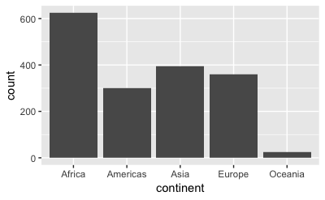

## Group

Coming soon

## Join

Coming soon

## Visualize

Coming soon

## Reshape

Coming soon